# ECON: Homework 4

Zoe Duerksen-Salm & Renata Massion

5/25/2020

**Baseline calculations for all questions:**

- Used R Studio for all questions
- We created variables for the given parameters (delta, eta, g, beta, and time t as a sequence of 0-200)
- We then created functions in R Studio for all five given equations (temperature, keep, consumption, utility, and Ramsey’s rule).

## Question #1: Plots

**Baseline calculations for question #1:**

- Create data frames for no climate change projection/scenario (T=0) and both potential climate change projections/scenarios (T=2 and T=8).
- Include in data frames:
  - **rows** for every year
  - **columns** for results from each function (temperature, keep, consumption, and utility)

#### A. Plot temperature over time

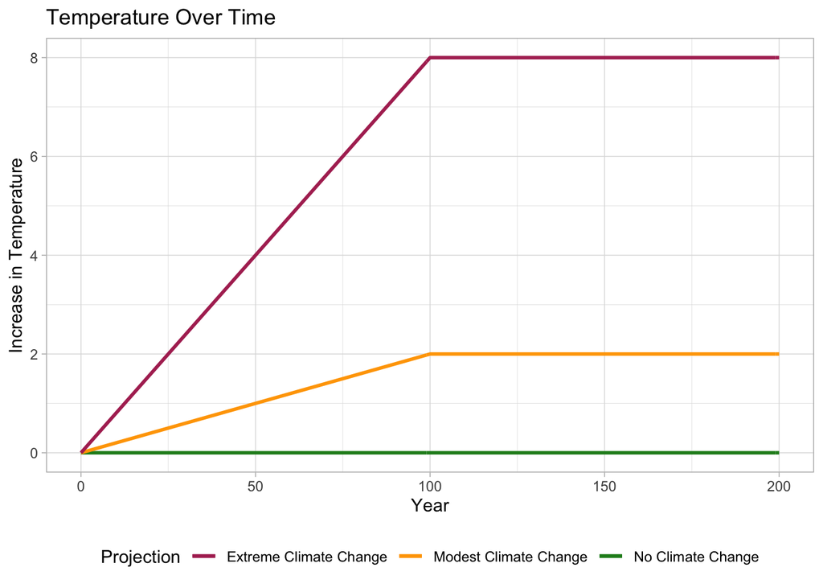

*Calculations:*

- Create a plot that combines information from the three previously created data frames. Plot year (0 to 200) on the x-axis and increase in temperature (calculated using temperature function/equation) on the y-axis.

#### B. Plot consumption over time

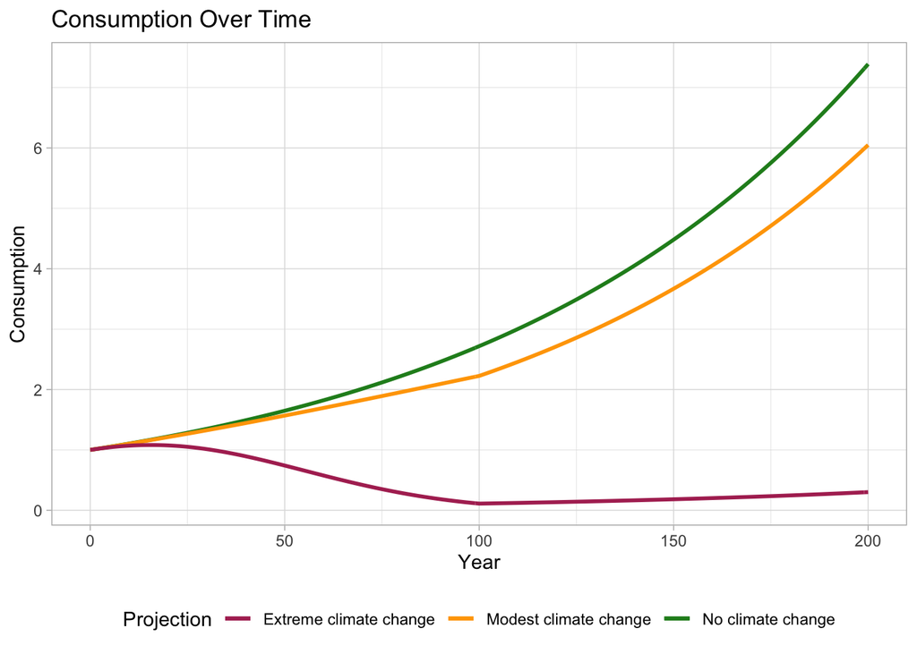

*Calculations:*

- Create a plot that combines information from the three previously created data frames. Plot year (0 to 200) on the x-axis and consumption (calculated using consumption function/equation) on the y-axis.

#### C. Plot undiscounted utility over time

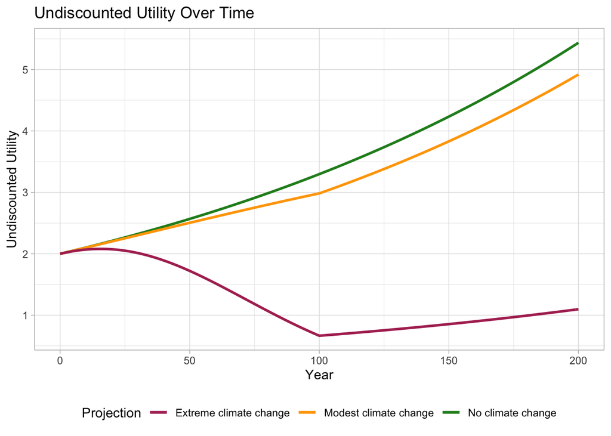

*Calculations:*

- Create a plot that combines information from the three previously created data frames. Plot year (0 to 200) on the x-axis and utility (calculated using utility function/equation) on the y-axis.

## Question #2: Analysis

#### A. T=4.4 under BAU

- Present value utility with climate change: **198.66**
- Present value utility without climate change: **255.27**
- Percent loss in PV utility from climate change (L): **-22.18%**

*Calculations:*

1. Create two data frames: (a) projections under no climate change and (b) projections under a T=4.4 climate change scenario.
   - Include rows for each year.
   - Mutate columns to represent each function and the present value of utility.
   - PV equation is [utility/((1+r)<sup>t</sup>)].
2. Individually sum PV columns from each data frame.
3. Calculate percent loss (L)
   - Equation: L = [ (PV with CC - PV without CC) / (PV without CC) ]

- Increase in **temperature**: % change in L = **16.32%**
- Increase in **g**: % change in L = **0.02%**
- Increase in **eta**: % change in L = **-11.64%**
- Increase in **beta**: % change in L = **7.94%**

*Calculations:*

- Use the same calculation steps from question 2A. BUT, run code 4 separate times (for no climate change scenario and T=4.4 climate change scenario), each run changing increasing one designated variable by 10%.
- **10% change in temp**
  - Increase temperature parameter by 10%. New temp for no CC = 0; new temp for CC 4.4 = 4.84.
    - (old no CC temp * 110%) > (0 * 1.1) > 0
    - (old CC temp * 110%) > (4.4 * 1.1) > 4.84
  - Find the new percent change using the same method as in 2A (summing PVs + % change formula).
  - Use the percent change formula to find the change from the previously calculated L, to the new L [ (New L - Old L) / (Old L) ].
- **10% change in g**
  - Increase g parameter by 10%. New g for both projections = 0.011.
    - (old g * 110%) > (0.01 * 1.1) > 0.011
  - Increasing the g parameter also requires recalculation of the discount value (by plugging the new g into the Ramsey equation).
    - new r = delta + (eta * (new g)) > new r = 0.005 + (0.5 * (0.011)) > new r = 0.0105
  - Find the new percent change using the same method as in 2A (summing PVs + % change formula).
  - Use the percent change formula to find the change from the previously calculated L, to the new L [ (New L - Old L) / (Old L) ].
- **10% change in eta**
  - Increase eta parameter by 10%. New eta = 0.55.
    - (old eta * 110%) > (0.5 * 1.1) > 0.55
  - Increasing the eta parameter also requires recalculation of the discount value (by plugging the new eta into the Ramsey equation).
    - new r = delta + ((new eta) * g) > new r = 0.005 + ((0.55) * 0.01) > new r = 0.0105
  - Find the new percent change using the same method as in 2A (summing PVs + % change formula).
  - Use the percent change formula to find the change from the previously calculated L, to the new L [ (New L - Old L) / (Old L) ].
- **10% change in beta**
  - Increase beta parameter by 10%. New beta = 0.055.
    - (old beta * 110%) > (0.05 * 1.1) > 0.055
  - Find the new percent change using the same method as in 2A (summing PVs + % change formula).
  - Use the percent change formula to find the change from the previously calculated L, to the new L [ (New L - Old L) / (Old L) ].

#### C. Maximum value of θ society would be willing to endure every year to completely prevent climate change.

θ∗ = **39.44%**

*Calculations:*

1. Set PV of discounted utility when T=4.4 equal to PV of discounted utility when T=0 multiplied by theta.
   - PV(4.4) = PV(0)*(theta)
2. Find NPV for each climate change scenario (4.4 vs. 0).
   - NPV(4.4) = NPV(0)*theta<sup>(1-eta)</sup>
3. Rearrange equation such that theta is on the left side of the equation.
   - theta = (NPV(4.4)/NPV(0))<sup>(1/(1-eta))</sup>
4. Plug NPV values into the equation.
   - theta = (198.66/255.2734)<sup>(1/(1-0.5))</sup>
   - theta = 0.6056333
5. Calculate theta* by doing 1-theta found in step 4 and multiplying by 100 to get a percentage.
   - theta* = (1 - 0.6056333)*100
   - theta* = 39.44%

#### D. θ∗ under uncertainty over T.

Uncertain θ = **37.79%**

*Calculations:*

1. Create a data frame for projections under 3 climate change scenarios (T=2, T=4, and T=6) projections under a T=4.4 climate change scenario.
   - Include rows for each year.
   - Mutate columns to represent calculated answer for each function and present value for a given projection.
2. Find NPV for each scenario by summing columns for PV values.
3. Determine total NPV under uncertainty using the equation: NPV = (p(2) * PV(2)) + (p(4) * PV(4)) + (p(6) * PV(6))
   - Where p = probability of that scenario.
   - NPV = (0.2 * 241.597) + (0.5 * 206.907) + (0.3 * 165.2395)
   - NPV = 201.3447
4. Plug NPV values for the uncertain scenario and the into the T=0 scenario into the equation in step 3 of question 2C.
   - NPV(uncertain) = NPV(0)*theta<sup>(1-eta)</sup>
5. Rearrange equation such that theta is on the left side of the equation.
   - theta = (NPV(uncertain)/NPV(0))<sup>(1/(1-eta))</sup>
6. Plug NPV values into the equation.
   - theta = (201.3447/255.2734)<sup>(1/(1-0.5))</sup>
   - theta = 0.622113
7. Calculate theta* by doing 1-theta found in step 6 and multiplying by 100 to get a percentage.
   - theta* = (1 - 0.622113)*100
   - theta* = 37.79%